# Predicting the Correctness of Dumbbell Biceps Curl Exercises

B. Laden

August 16, 2014

### Executive Summary

The report seeks to answer the question: Can the correctness of an exercise be predicted by sensor data? It uses bagging and random forest to construct a prediction model. The random forest model has the lowest error rate for prediction, 3.3%. The model was applied to a small set of test data for which the outcome is unknown.

### The Question

If you’ve ever worked out with a personal trainer, you’ll understand not only the importance of exercise, but of performing each exercise correctly. Incorrect movements can result in toning the wrong muscles, not toning the full range of a muscle, and, more seriously, back injury.

Velloso, Bulling, Gellersen, Ugulino, and Fuks (2013) used sensors to collect data from 6 people who were performing bicep curls. The subjects were instructed to perform the exercise in five different ways:

- Exactly according to the specification (class A)
- Throwing the elbows to the front (class B)
- Lifting the dumbbell only halfway (class C)
- Lowering the dumbbell only halfway (class D)
- Throwing the hips to the front (class E)

The question they examined in their paper, and what I attempt to answer in this report, is: Can the correctness of an exercise be predicted by sensor data?

### Getting the Data

I used two datasets. The first consists of 19,622 observations of 160 variables. The second has 20 observations of 160 variables.The first set has a “classe”" variable that specifies how the subject performed the exercise (see previous section). The second set does not contain a “classe”" variable.

```r
fileURL1 <- "https://d396qusza40orc.cloudfront.net/predmachlearn/pml-training.csv"
fileURL2 <- "https://d396qusza40orc.cloudfront.net/predmachlearn/pml-testing.csv"
download.file(fileURL1,destfile="pml-training.csv",method="curl")
download.file(fileURL2,destfile="pml-testing.csv",method="curl")
weightsData <- read.csv("pml-training.csv")
smallTestData <- read.csv("pml-testing.csv")
```

I’ll use the first dataset (weightsData) to build and validate a machine learning algorithm. I’ll make predictions for the smaller test set (smallTest).

### Cleaning and Subsetting the Data

When I looked at the head of the weights dataset, I noticed many columns had NA entries. Upon further inspection, NA appeared to run the full length of many columns, with only an occasional entry. Other variables, such as new_window, num_window, user_name, and several columns of timestamp data didn’t seem useful. So I removed the NA columns as well as these other columns. I also removed the belt-related data. While thursting one’s hips forward is certainly an incorrect move for a bicep curl, I suspect the forearm, arm, and dumbell movements will reflect this type of incorrect movement. (Also, I’ve spent a lot of time in the gym; the hip-thrusters also tend to flail their arms.) I used the subset command to pare down each dataset to 25 predictors. As you can see, the weights data has the outcome—classe—while the smallTest dataset does not.

```r
weights <- subset(weightsData,select=c(classe,roll_arm, pitch_arm, yaw_arm,
               total_accel_arm, gyros_arm_x, gyros_arm_y,gyros_arm_z,
               accel_arm_x, accel_arm_y, accel_arm_z, magnet_arm_x,magnet_arm_y,magnet_arm_z,
               roll_dumbbell,pitch_dumbbell, yaw_dumbbell,gyros_forearm_x, gyros_forearm_y,
               gyros_forearm_z, accel_forearm_x, accel_forearm_y,accel_forearm_z, magnet_forearm_x,
               magnet_forearm_y,magnet_forearm_z))
smallTest <- subset(smallTestData,select=c(roll_arm, pitch_arm, yaw_arm,
               total_accel_arm, gyros_arm_x, gyros_arm_y,gyros_arm_z,
               accel_arm_x, accel_arm_y, accel_arm_z, magnet_arm_x,magnet_arm_y,magnet_arm_z,
               roll_dumbbell,pitch_dumbbell, yaw_dumbbell, gyros_forearm_x, gyros_forearm_y,
               gyros_forearm_z, accel_forearm_x, accel_forearm_y,accel_forearm_z, magnet_forearm_x,
               magnet_forearm_y,magnet_forearm_z))
```

Note that Velloso, et al. used 13 predictors in their paper. My purpose here is not to reproduce what they did, but to explore this dataset myself.

The weights data set needs to be partitioned into training and testing data. That way, I can train and validate the predictions. I chose 60% as the split between training and testing.

```r
require(caret)
train <- createDataPartition(y=weights$classe,p=0.6,list=FALSE)
```

### Constructing Prediction Algorithms

I decided to use bagging and random forest to construct a prediction algorithm. Given the number of predictors, I decided to try a few approaches and choose the one with the lowest prediction error.

#### Bagging

I followed an approach outlined in *An Introduction to Statistical Learning* (2013) in which the randomForest function is used to perform bagging by setting m = p. As you can see, all 25 predictors will be tried at every branch of the decision tree.

```r
require(randomForest)
set.seed(1)
bag.weights = randomForest(classe~.,data=weights,subset=train,mtry=25,importance=TRUE)
```

```r
bag.weights$conf
```

```
##      A    B    C    D    E class.error
## A 3253   29   34   25    7     0.02838
## B   51 2166   32   11   19     0.04958
## C   17   48 1953   27    9     0.04917
## D   13   15   77 1794   31     0.07047
## E    5   46   25   32 2057     0.04988
```

Next I’ll see how well the bagging model performs on the testing subset of the weights dataset:

```r
yhat.bag <- predict(bag.weights,newdata=weights[-train,])
actual <- weights[-train,"classe"]
correct <- yhat.bag == actual
errorRate <- 1.0 - sum(correct)/length(correct)
errorRate
```

```
## [1] 0.04805
```

The model uses 500 trees. Could it be improved by using fewer? Next I add the ntrees parameter, setting it to 50 to see if I can get a lower error rate.

```r
set.seed(1)
bag.weights = randomForest(classe~.,data=weights,subset=train,mtry=25,ntree=50)
```

```r
yhat.bag <- predict(bag.weights,newdata=weights[-train,])
actual <- weights[-train,"classe"]
correct <- yhat.bag == actual
errorRate <- 1.0 - sum(correct)/length(correct)
errorRate
```

```
## [1] 0.05277
```

#### Random Forest

Next I tried a random forest model. I used the same function, but set mtry to a smaller value to use random forest rather than bagging (recall, for bagging m = p). The randomForest function should default to the square root of the predictors for mtry, but I explictly entered it here. (5 = square root of 25).

```r
set.seed(1)
rf.weights = randomForest(classe~.,data=weights,subset=train,mtry=5,importance=TRUE)
```

```r
rf.weights$conf
```

```
##      A    B    C    D    E class.error
## A 3288   16   16   20    8     0.01792
## B   42 2197   24    8    8     0.03598
## C    5   42 1985   17    5     0.03359
## D    6    6   79 1810   29     0.06218
## E    1   27    9   27 2101     0.02956
```

The prediction rate for the testing subset is 3.30%.

```r
yhat.rf <- predict(rf.weights,newdata=weights[-train,])
actual <- weights[-train,"classe"]
correct <- yhat.rf == actual
errorRate <- 1.0 - sum(correct)/length(correct)
errorRate
```

```
## [1] 0.03263
```

The random forest model appears to do a better job predicting the outcome.

#### Importance

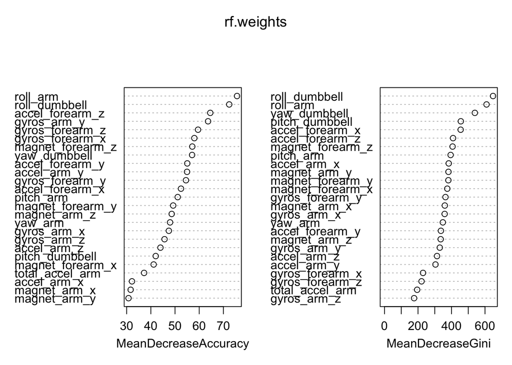

```r
varImpPlot(rf.weights)
```

#### Cross Validation

According to the Random Forests Manual (Breiman and Cutler), random forest does its own internal cross validation. That’s why I did not not perform any additional computations—they are built-in to random forest.

Note also that I split the large dataset (weights) into training and testing subsets. Thus I was able to validate the prediction function by using the testing subset of the weights dataset.

### Predicting the Outcome of New Data

[output not shown]

### Conclusion

There might be a way—either through data exploration or improvement of sensors—to reduce the data needed for prediction. Less data will mean better real-time performance for a “digital personal trainer.” Real-time feedback is critical to improving at exercise.

### Bibliography

Velloso, E.; Bulling, A.; Gellersen, H.; Ugulino, W.; Fuks, H. *Qualitative Activity Recognition of Weight Lifting Exercises*. Proceedings of 4th International Conference in Cooperation with SIGCHI (Augmented Human 13) . Stuttgart, Germany: ACM SIGCHI, 2013.

James, G.; Witten, D.; Hastie, T; and Tibshirani, R. *An Introduction to Statistical Learning with Applications in R*, Springer, 2013.

Breiman, L. and Cutler, A. *Random Forests Manual*. http://www.stat.berkeley.edu/~breiman/RandomForests/cc_home.htm#ooberr